# Data Analysis Assignment W09

Callum Arnold

# Introduction

This week’s assignment was to evaluate the performance of different kernel methods of support vector machnines, and the underlying method of support vectior classifiers, to explore which variables act as predictors of which brand of orange juice was purchased in the `OJ` dataset. To compare the methods’ predictive power, the data was split into training and test data sets, a range of cost, gamma, and degree parameters were evaluated using test error rates. The methods evaluated were: support vector classifier (SVC), and support vector machines using either a polynomial kernel (SVM-P) (degree = 2) or a radial kernel (SVM-R) (default gamma = 0.06 [`1 / ncol(OJ)`]). SVC performed the most consistently on the training and the test data set, with `cost` having little effect on the accuracy, whereas both SVM methods were heavily affected by the `cost`. After optimization of `cost` using 10-fold cross-validation, SVM-R performed the best, with an accuracy of 0.819 on the test data, and the lower variance between training and test performance relative to SVM-P.

```r
library(ISLR)
library(tidyverse)
library(caret)
library(e1071)
library(ROCR)
library(kableExtra)
library(hrbrthemes)
library(janitor)
library(rsample)

RNGkind(sample.kind = "Rounding")
set.seed(1)

theme_set(theme_ipsum())
```

# Data

```r
data("OJ")
glimpse(OJ)
```

[output not shown]

The `OJ` data from ISLR is a dataset that contains over 1000 purchase records of either “Citrus Hill” or “Minute Maid” brands of orange juice, and 17 variables that are possible predictors of the purchase brand. The predictor variable descriptions are listed below.

```r
tibble(
  Variable = names(OJ),
  Description = c(
    "A factor with levels CH and MM indicating whether the customer purchased Citrus Hill or Minute Maid Orange Juice",
    "Week of purchase",
    "Store ID",
    "Price charged for CH",
    "Price charged for MM",
    "Discount offered for CH",
    "Discount offered for MM",
    "Indicator of special on CH",
    "Indicator of special on MM",
    "Customer brand loyalty for CH",
    "Sale price for MM",
    "Sale price for CH",
    "Sale price of MM less sale price of CH",
    "A factor with levels No and Yes indicating whether the sale is at Store 7",
    "Percentage discount for MM",
    "Percentage discount for CH",
    "List price of MM less list price of CH",
    "Which of 5 possible stores the sale occured at"
  )
) %>%
    kable() %>%
    kable_styling(
        bootstrap_options = c("striped", "hover", "condensed", "responsive"),
        full_width = F)
```

| Variable | Description |
| --- | --- |
| Purchase | A factor with levels CH and MM indicating whether the customer purchased Citrus Hill or Minute Maid Orange Juice |
| WeekofPurchase | Week of purchase |
| StoreID | Store ID |
| PriceCH | Price charged for CH |
| PriceMM | Price charged for MM |
| DiscCH | Discount offered for CH |
| DiscMM | Discount offered for MM |
| SpecialCH | Indicator of special on CH |
| SpecialMM | Indicator of special on MM |
| LoyalCH | Customer brand loyalty for CH |
| SalePriceMM | Sale price for MM |
| SalePriceCH | Sale price for CH |
| PriceDiff | Sale price of MM less sale price of CH |
| Store7 | A factor with levels No and Yes indicating whether the sale is at Store 7 |
| PctDiscMM | Percentage discount for MM |
| PctDiscCH | Percentage discount for CH |
| ListPriceDiff | List price of MM less list price of CH |
| STORE | Which of 5 possible stores the sale occured at |

## Data Pre-Processing

```r
set.seed(1)

oj_split <- initial_split(OJ, prop = 800 / nrow(OJ))
train_data <- training(oj_split)
test_dat <- testing(oj_split)
```

# Support Vector Classifier

SVC performed well at correctly classifying the purchased brand on the basis of the predictor variables and was relatively unaffected by the `cost`: the accuracy of the initial and optimized SVC on the training data was similar (0.834 vs 0.0.850) and the testing data was the same (0.815). 435 support vectors were used in the original SVC, and when optimized (`cost` = 1), 327 support vectors were used. Upon optimization there was an 81.5% accuracy rate on the test data. The p-value associated with the `Acc > NIR` is $ <2e-16 $. This indicates the probability of the accuracy exceeding that of randomly allocating classes (`No Information Rate`). With a $ p < 2e-16 $, the optimized SVC is a significant improvement over random chance. With a sensitivity of 84.5% and specificity of 77.4% (on the test data, with respect to `CH` as the positive result), the SVM was able to more accurately identify `CH` purchases than `MM` purchases.

```r
svc_fit <- svm(
    Purchase ~ .,
    data = train_data,
    kernel = "linear",
    cost = 0.01)
```

```r
summary(svc_fit)
```

```
Call:
svm(formula = Purchase ~ ., data = train_data, kernel = "linear", cost = 0.01)


Parameters:
   SVM-Type:  C-classification
 SVM-Kernel:  linear
       cost:  0.01

Number of Support Vectors:  435

 ( 218 217 )


Number of Classes:  2

Levels:
 CH MM
```

```r
svc_ypred_train <- predict(svc_fit, newdata = train_data)
confusionMatrix(svc_ypred_train, reference = train_data$Purchase)
```

```
Confusion Matrix and Statistics

          Reference
Prediction  CH  MM
        CH 441  76
        MM  57 226

               Accuracy : 0.8338
                 95% CI : (0.8061, 0.8589)
    No Information Rate : 0.6225
    P-Value [Acc > NIR] : <2e-16

                  Kappa : 0.6418

 Mcnemar's Test P-Value : 0.1186

            Sensitivity : 0.8855
            Specificity : 0.7483
         Pos Pred Value : 0.8530
         Neg Pred Value : 0.7986
             Prevalence : 0.6225
         Detection Rate : 0.5513
   Detection Prevalence : 0.6462
      Balanced Accuracy : 0.8169

       'Positive' Class : CH
```

```r
svc_ypred_test <- predict(svc_fit, newdata = test_dat)
confusionMatrix(svc_ypred_test, reference = test_dat$Purchase)
```

```
Confusion Matrix and Statistics

          Reference
Prediction  CH  MM
        CH 134  29
        MM  21  86

               Accuracy : 0.8148
                 95% CI : (0.7633, 0.8593)
    No Information Rate : 0.5741
    P-Value [Acc > NIR] : <2e-16

                  Kappa : 0.6179

 Mcnemar's Test P-Value : 0.3222

            Sensitivity : 0.8645
            Specificity : 0.7478
         Pos Pred Value : 0.8221
         Neg Pred Value : 0.8037
             Prevalence : 0.5741
         Detection Rate : 0.4963
   Detection Prevalence : 0.6037
      Balanced Accuracy : 0.8062

       'Positive' Class : CH
```

## Tuning optimal cost

```r
svc_tuned <- tune(
  svm,
  Purchase ~ .,
  data = train_data,
  kernel = "linear",
  ranges = list(cost = c(0.01, 0.1, 1, 3, 6, 10))
)

summary(svc_tuned)
```

```
Parameter tuning of ‘svm’:

- sampling method: 10-fold cross validation

- best parameters:
```

|  | cost |
| --- | --- |
|  | 1 |

```
- best performance: 0.16

- Detailed performance results:
```

| cost | error | dispersion |
| --- | --- | --- |
| 0.01 | 0.17500 | 0.03908680 |
| 0.10 | 0.16875 | 0.03448530 |
| 1.00 | 0.16000 | 0.04158325 |
| 3.00 | 0.16000 | 0.04031129 |
| 6.00 | 0.16625 | 0.03682259 |
| 10.00 | 0.16750 | 0.04174992 |

```r
svc_bestmod <- svc_tuned$best.model

summary(svc_bestmod)
```

```
Call:
best.tune(method = svm, train.x = Purchase ~ ., data = train_data, ranges = list(cost = c(0.01,
    0.1, 1, 3, 6, 10)), kernel = "linear")


Parameters:
   SVM-Type:  C-classification
 SVM-Kernel:  linear
       cost:  1

Number of Support Vectors:  327

 ( 164 163 )


Number of Classes:  2

Levels:
 CH MM
```

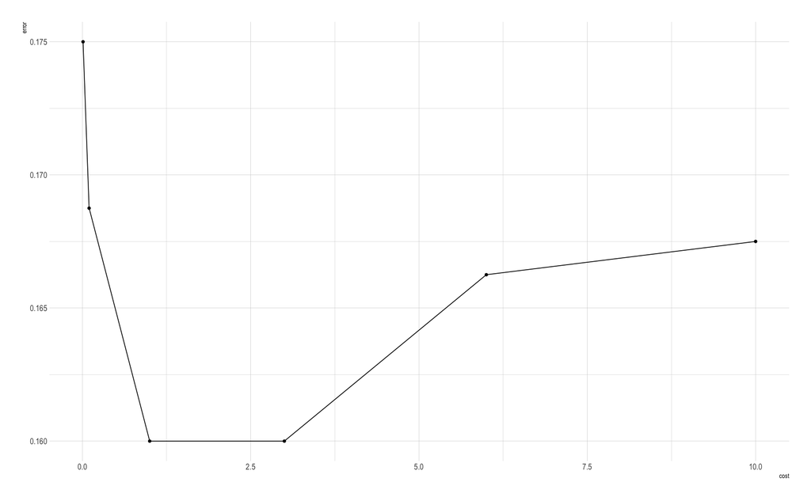

```r
svc_tuned$performances %>%
  ggplot(aes(cost, error)) +
  geom_point() +
  geom_line()
```

```r
svc_best_ypred_train <- predict(svc_bestmod, newdata = train_data)
confusionMatrix(svc_best_ypred_train, reference = train_data$Purchase)
```

```
Confusion Matrix and Statistics

          Reference
Prediction  CH  MM
        CH 442  64
        MM  56 238

               Accuracy : 0.85
                 95% CI : (0.8233, 0.874)
    No Information Rate : 0.6225
    P-Value [Acc > NIR] : <2e-16

                  Kappa : 0.6792

 Mcnemar's Test P-Value : 0.5228

            Sensitivity : 0.8876
            Specificity : 0.7881
         Pos Pred Value : 0.8735
         Neg Pred Value : 0.8095
             Prevalence : 0.6225
         Detection Rate : 0.5525
   Detection Prevalence : 0.6325
      Balanced Accuracy : 0.8378

       'Positive' Class : CH
```

```r
svc_best_ypred_test <- predict(svc_bestmod, newdata = test_dat)
confusionMatrix(svc_best_ypred_test, reference = test_dat$Purchase)
```

```
Confusion Matrix and Statistics

          Reference
Prediction  CH  MM
        CH 131  26
        MM  24  89

               Accuracy : 0.8148
                 95% CI : (0.7633, 0.8593)
    No Information Rate : 0.5741
    P-Value [Acc > NIR] : <2e-16

                  Kappa : 0.6205

 Mcnemar's Test P-Value : 0.8875

            Sensitivity : 0.8452
            Specificity : 0.7739
         Pos Pred Value : 0.8344
         Neg Pred Value : 0.7876
             Prevalence : 0.5741
         Detection Rate : 0.4852
   Detection Prevalence : 0.5815
      Balanced Accuracy : 0.8095

       'Positive' Class : CH
```

# Support Vector Machine

## Radial Kernel

SVM-R performed well at correctly classifying the purchased brand on the basis of the predictor variables once optimized, but was strongly affected by the `cost`: the accuracy of the initial and optimized SVM-R on the training data was very dissimilar (0.623 vs 0.853) as well as the testing data (0.574 vs 0.819). The smaller difference in train vs test performance in the optimized SVM-R illustrates a lower variance, in addition to a reduced bias. 607 support vectors were used in the original SVM-R, with such wide margins that all predictions were `CH` brand, and when optimized (`cost` = 1), 364 support vectors were used. Upon optimization there was an 81.9% accuracy rate on the test data. The p-value associated with the `Acc > NIR` is $ <2e-16 $. This indicates the probability of the accuracy exceeding that of randomly allocating classes (`No Information Rate`). With a $ p < 2e-16 $, the optimized SVC is a significant improvement over random chance. With a sensitivity of 89.0% and specificity of 72.2% (on the test data, with respect to `CH` as the positive result), the SVM-R was able to more accurately identify `CH` purchases than `MM` purchases.

```r
svm_rad_fit <- svm(
    Purchase ~ .,
    data = train_data,
    kernel = "radial",
    cost = 0.01)
```

```r
summary(svm_rad_fit)
```

```
Call:
svm(formula = Purchase ~ ., data = train_data, kernel = "radial", cost = 0.01)


Parameters:
   SVM-Type:  C-classification
 SVM-Kernel:  radial
       cost:  0.01

Number of Support Vectors:  607

 ( 305 302 )


Number of Classes:  2

Levels:
 CH MM
```

```r
svm_rad_ypred_train <- predict(svm_rad_fit, newdata = train_data)
confusionMatrix(svm_rad_ypred_train, reference = train_data$Purchase)
```

```
Confusion Matrix and Statistics

          Reference
Prediction  CH  MM
        CH 498 302
        MM   0   0

               Accuracy : 0.6225
                 95% CI : (0.5879, 0.6562)
    No Information Rate : 0.6225
    P-Value [Acc > NIR] : 0.5157

                  Kappa : 0

 Mcnemar's Test P-Value : <2e-16

            Sensitivity : 1.0000
            Specificity : 0.0000
         Pos Pred Value : 0.6225
         Neg Pred Value :    NaN
             Prevalence : 0.6225
         Detection Rate : 0.6225
   Detection Prevalence : 1.0000
      Balanced Accuracy : 0.5000

       'Positive' Class : CH
```

```r
svm_rad_ypred_test <- predict(svm_rad_fit, newdata = test_dat)
confusionMatrix(svm_rad_ypred_test, reference = test_dat$Purchase)
```

```
Confusion Matrix and Statistics

          Reference
Prediction  CH  MM
        CH 155 115
        MM   0   0

               Accuracy : 0.5741
                 95% CI : (0.5127, 0.6338)
    No Information Rate : 0.5741
    P-Value [Acc > NIR] : 0.5257

                  Kappa : 0

 Mcnemar's Test P-Value : <2e-16

            Sensitivity : 1.0000
            Specificity : 0.0000
         Pos Pred Value : 0.5741
         Neg Pred Value :    NaN
             Prevalence : 0.5741
         Detection Rate : 0.5741
   Detection Prevalence : 1.0000
      Balanced Accuracy : 0.5000

       'Positive' Class : CH
```

### Tuning optimal cost

```r
svm_rad_tuned <- tune(
  svm,
  Purchase ~ .,
  data = train_data,
  kernel = "radial",
  ranges = list(cost = c(0.01, 0.1, 1, 3, 6, 10))
)

summary(svm_rad_tuned)
```

```
Parameter tuning of ‘svm’:

- sampling method: 10-fold cross validation

- best parameters:
```

|  | cost |
| --- | --- |
|  | 1 |

```
- best performance: 0.17125

- Detailed performance results:
```

| cost | error | dispersion |
| --- | --- | --- |
| 0.01 | 0.37750 | 0.04479893 |
| 0.10 | 0.18250 | 0.04257347 |
| 1.00 | 0.17125 | 0.04084609 |
| 3.00 | 0.17875 | 0.03729108 |
| 6.00 | 0.18875 | 0.04348132 |
| 10.00 | 0.18750 | 0.03818813 |

```r
svm_rad_bestmod <- svm_rad_tuned$best.model

summary(svm_rad_bestmod)
```

```
Call:
best.tune(method = svm, train.x = Purchase ~ ., data = train_data, ranges = list(cost = c(0.01,
    0.1, 1, 3, 6, 10)), kernel = "radial")


Parameters:
   SVM-Type:  C-classification
 SVM-Kernel:  radial
       cost:  1

Number of Support Vectors:  364

 ( 184 180 )


Number of Classes:  2

Levels:
 CH MM
```

[figure not shown]

```r
svm_rad_best_ypred_train <- predict(svm_rad_bestmod, newdata = train_data)
confusionMatrix(svm_rad_best_ypred_train, reference = train_data$Purchase)
```

```
Confusion Matrix and Statistics

          Reference
Prediction  CH  MM
        CH 454  74
        MM  44 228

               Accuracy : 0.8525
                 95% CI : (0.826, 0.8764)
    No Information Rate : 0.6225
    P-Value [Acc > NIR] : < 2.2e-16

                  Kappa : 0.6799

 Mcnemar's Test P-Value : 0.007593

            Sensitivity : 0.9116
            Specificity : 0.7550
         Pos Pred Value : 0.8598
         Neg Pred Value : 0.8382
             Prevalence : 0.6225
         Detection Rate : 0.5675
   Detection Prevalence : 0.6600
      Balanced Accuracy : 0.8333

       'Positive' Class : CH
```

```r
svm_rad_best_ypred_test <- predict(svm_rad_bestmod, newdata = test_dat)
confusionMatrix(svm_rad_best_ypred_test, reference = test_dat$Purchase)
```

```
Confusion Matrix and Statistics

          Reference
Prediction  CH  MM
        CH 138  32
        MM  17  83

               Accuracy : 0.8185
                 95% CI : (0.7673, 0.8626)
    No Information Rate : 0.5741
    P-Value [Acc > NIR] : <2e-16

                  Kappa : 0.6225

 Mcnemar's Test P-Value : 0.0455

            Sensitivity : 0.8903
            Specificity : 0.7217
         Pos Pred Value : 0.8118
         Neg Pred Value : 0.8300
             Prevalence : 0.5741
         Detection Rate : 0.5111
   Detection Prevalence : 0.6296
      Balanced Accuracy : 0.8060

       'Positive' Class : CH
```

## Polynomial Kernel

```r
svm_poly_fit <- svm(
    Purchase ~ .,
    data = train_data,
    kernel = "polynomial",
    cost = 0.01,
    degree = 2)
```

```r
summary(svm_poly_fit)
```

```
Call:
svm(formula = Purchase ~ ., data = train_data, kernel = "polynomial",
    cost = 0.01, degree = 2)


Parameters:
   SVM-Type:  C-classification
 SVM-Kernel:  polynomial
       cost:  0.01
     degree:  2
     coef.0:  0

Number of Support Vectors:  611

 ( 309 302 )


Number of Classes:  2

Levels:
 CH MM
```

```r
svm_poly_ypred_train <- predict(svm_poly_fit, newdata = train_data)
confusionMatrix(svm_poly_ypred_train, reference = train_data$Purchase)
```

```
Confusion Matrix and Statistics

          Reference
Prediction  CH  MM
        CH 493 281
        MM   5  21

               Accuracy : 0.6425
                 95% CI : (0.6082, 0.6758)
    No Information Rate : 0.6225
    P-Value [Acc > NIR] : 0.129

                  Kappa : 0.0725

 Mcnemar's Test P-Value : <2e-16

            Sensitivity : 0.98996
            Specificity : 0.06954
         Pos Pred Value : 0.63695
         Neg Pred Value : 0.80769
             Prevalence : 0.62250
         Detection Rate : 0.61625
   Detection Prevalence : 0.96750
      Balanced Accuracy : 0.52975

       'Positive' Class : CH
```

```r
svm_poly_ypred_test <- predict(svm_poly_fit, newdata = test_dat)
confusionMatrix(svm_poly_ypred_test, reference = test_dat$Purchase)
```

```
Confusion Matrix and Statistics

          Reference
Prediction  CH  MM
        CH 153 107
        MM   2   8

               Accuracy : 0.5963
                 95% CI : (0.5351, 0.6553)
    No Information Rate : 0.5741
    P-Value [Acc > NIR] : 0.2498

                  Kappa : 0.0642

 Mcnemar's Test P-Value : <2e-16

            Sensitivity : 0.98710
            Specificity : 0.06957
         Pos Pred Value : 0.58846
         Neg Pred Value : 0.80000
             Prevalence : 0.57407
         Detection Rate : 0.56667
   Detection Prevalence : 0.96296
      Balanced Accuracy : 0.52833

       'Positive' Class : CH
```

### Tuning optimal cost

```r
svm_poly_tuned <- tune(
  svm,
  Purchase ~ .,
  data = train_data,
  kernel = "polynomial",
  ranges = list(cost = c(0.01, 0.1, 1, 3, 6, 10)),
  degree = 2
)

summary(svm_poly_tuned)
```

```
Parameter tuning of ‘svm’:

- sampling method: 10-fold cross validation

- best parameters:
```

|  | cost |
| --- | --- |
|  | 10 |

```
- best performance: 0.1775

- Detailed performance results:
```

| cost | error | dispersion |
| --- | --- | --- |
| 0.01 | 0.37250 | 0.05394184 |
| 0.10 | 0.31000 | 0.05230785 |
| 1.00 | 0.19375 | 0.05212498 |
| 3.00 | 0.18875 | 0.04875178 |
| 6.00 | 0.18125 | 0.05212498 |
| 10.00 | 0.17750 | 0.04958158 |

```r
svm_poly_bestmod <- svm_poly_tuned$best.model

summary(svm_poly_bestmod)
```

```
Call:
best.tune(method = svm, train.x = Purchase ~ ., data = train_data, ranges = list(cost = c(0.01,
    0.1, 1, 3, 6, 10)), kernel = "polynomial", degree = 2)


Parameters:
   SVM-Type:  C-classification
 SVM-Kernel:  polynomial
       cost:  10
     degree:  2
     coef.0:  0

Number of Support Vectors:  343

 ( 176 167 )


Number of Classes:  2

Levels:
 CH MM
```

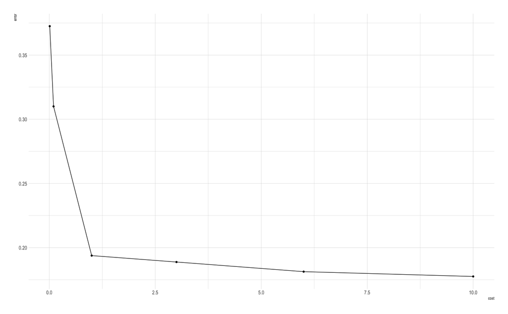

```r
svm_poly_tuned$performances %>%
  ggplot(aes(cost, error)) +
  geom_point() +
  geom_line()
```

```r
svm_poly_best_ypred_train <- predict(svm_poly_bestmod, newdata = train_data)
confusionMatrix(svm_poly_best_ypred_train, reference = train_data$Purchase)
```

```
Confusion Matrix and Statistics

          Reference
Prediction  CH  MM
        CH 459  66
        MM  39 236

               Accuracy : 0.8688
                 95% CI : (0.8434, 0.8914)
    No Information Rate : 0.6225
    P-Value [Acc > NIR] : < 2e-16

                  Kappa : 0.7157

 Mcnemar's Test P-Value : 0.01117

            Sensitivity : 0.9217
            Specificity : 0.7815
         Pos Pred Value : 0.8743
         Neg Pred Value : 0.8582
             Prevalence : 0.6225
         Detection Rate : 0.5737
   Detection Prevalence : 0.6562
      Balanced Accuracy : 0.8516

       'Positive' Class : CH
```

```r
svm_poly_best_ypred_test <- predict(svm_poly_bestmod, newdata = test_dat)
confusionMatrix(svm_poly_best_ypred_test, reference = test_dat$Purchase)
```

```
Confusion Matrix and Statistics

          Reference
Prediction  CH  MM
        CH 137  38
        MM  18  77

               Accuracy : 0.7926
                 95% CI : (0.7393, 0.8394)
    No Information Rate : 0.5741
    P-Value [Acc > NIR] : 3.053e-14

                  Kappa : 0.5661

 Mcnemar's Test P-Value : 0.01112

            Sensitivity : 0.8839
            Specificity : 0.6696
         Pos Pred Value : 0.7829
         Neg Pred Value : 0.8105
             Prevalence : 0.5741
         Detection Rate : 0.5074
   Detection Prevalence : 0.6481
      Balanced Accuracy : 0.7767

       'Positive' Class : CH
```

# Conclusion

Based on the accuracy observed in the training and the test data, the simple SVC performed the best without optimization. However, there was little improvement upon optimization, with SVM-R outperforming it with training and test accuracy, although it exhibited slightly higher variance than SVC. SVM-P showed similar performance to SVM-R, improving greatly with optimization of `cost`, although it was not the most performant model. On this dataset, SVM-R would be selected as the final model due to its improved accuracy on both the training and test data.

```r
tibble(
  Statistic = c(
    "SVC Train",
    "SVC Test",
    "SVC Train",
    "SVC Test",
    "SVM Radial Train",
    "SVM Radial Test",
    "SVM Radial Train",
    "SVM Radial Test",
    "SVM Polynomial Train",
    "SVM Polynomial Test",
    "SVM Polynomial Train",
    "SVM Polynomial Test"
  ),
  `Cost` = c(
    "0.01",
    "0.01",
    "1",
    "1",
    "0.01",
    "0.01",
    "1",
    "1",
    "0.01",
    "0.01",
    "10",
    "10"
  ),
  `Accuracy` = c(
    "0.834",
    "0.815",
    "0.85",
    "0.815",
    "0.623",
    "0.574",
    "0.853",
    "0.819",
    "0.643",
    "0.596",
    "0.869",
    "0.793"
  ),
  `95% CI` = c(
    "0.806 - 0.859",
    "0.763 - 0.859",
    "0.823 - 0.874",
    "0.763 - 0.859",
    "0.588 - 0.656",
    "0.513 - 0.634",
    "0.826 - 0.876",
    "0.767 - 0.863",
    "0.608 - 0.676",
    "0.535 - 0.655",
    "0.843 - 0.891",
    "0.739 - 0.839"
  ),
  `No Information` = c(
    "0.623",
    "0.574",
    "0.623",
    "0.574",
    "0.623",
    "0.574",
    "0.623",
    "0.574",
    "0.623",
    "0.574",
    "0.623",
    "0.574"
  ),
  `P-Value [Acc > NIR]` = c(
    "< 2e-16",
    "< 2e-16",
    "< 2e-16",
    "< 2e-16",
    "0.516",
    "0.526",
    "< 2.2e-16",
    "< 2e-16",
    "0.129",
    "0.250",
    "< 2e-16",
    "3.05e-14"
  )
) %>%
  kable() %>%
  kable_styling(
    bootstrap_options = c("striped", "hover", "condensed", "responsive"),
    full_width = TRUE
  ) %>%
  row_spec(row = 7:8, bold = TRUE)
```

| Statistic | Cost | Accuracy | 95% CI | No Information | P-Value [Acc > NIR] |
| --- | --- | --- | --- | --- | --- |
| SVC Train | 0.01 | 0.834 | 0.806 - 0.859 | 0.623 | < 2e-16 |
| SVC Test | 0.01 | 0.815 | 0.763 - 0.859 | 0.574 | < 2e-16 |
| SVC Train | 1 | 0.85 | 0.823 - 0.874 | 0.623 | < 2e-16 |
| SVC Test | 1 | 0.815 | 0.763 - 0.859 | 0.574 | < 2e-16 |
| SVM Radial Train | 0.01 | 0.623 | 0.588 - 0.656 | 0.623 | 0.516 |
| SVM Radial Test | 0.01 | 0.574 | 0.513 - 0.634 | 0.574 | 0.526 |
| SVM Radial Train | 1 | 0.853 | 0.826 - 0.876 | 0.623 | < 2.2e-16 |
| SVM Radial Test | 1 | 0.819 | 0.767 - 0.863 | 0.574 | < 2e-16 |
| SVM Polynomial Train | 0.01 | 0.643 | 0.608 - 0.676 | 0.623 | 0.129 |
| SVM Polynomial Test | 0.01 | 0.596 | 0.535 - 0.655 | 0.574 | 0.250 |
| SVM Polynomial Train | 10 | 0.869 | 0.843 - 0.891 | 0.623 | < 2e-16 |
| SVM Polynomial Test | 10 | 0.793 | 0.739 - 0.839 | 0.574 | 3.05e-14 |